# Temporal trends

```r
filtered_dataset$abun_rich_op %>%
  filter(siteid %in% site_desc_slope_total_abundance[1:20]) %>%
  group_by(siteid) %>%
  summarise(across(c("total_abundance", "species_nb"), list(median = median, mean = mean)))
```

```
#> # A tibble: 20 x 5
#>    siteid total_abundance_med~ total_abundance~ species_nb_medi~ species_nb_mean
#>    <chr>                 <dbl>            <dbl>            <dbl>           <dbl>
#>  1 S1025              2534.               2960.             21             19.1
#>  2 S11735             5948               17416.             18             18.7
#>  3 S1199                 0.443            5760.              8              8.67
#>  4 S1661             10700               13043.              9              9
#>  5 S1698               314.                866              14             12
#>  6 S1787              2790.               2498.             16.5           15.7
#>  7 S2371              6251                7982.             28             27.8
#>  8 S2779              2510                7132.             23             24.2
#>  9 S3655              2298                3689.             23             23.3
#> 10 S3863              1827                3353.             13             13.6
#> 11 S430               1987                3201.             12.5           12.5
#> 12 S435               2847                3087.             16             15.4
#> 13 S436               1936                2506.             19             20
#> 14 S4501              2111                1924.             16             14.9
#> 15 S5180              4335                8431.             23             23.3
#> 16 S524              27971               22155.             26             25.3
#> 17 S5812              4968               12216.             24.5           25.2
#> 18 S6466              3166                6465.             27             25.7
#> 19 S8158              3610                5140.             24.5           24.7
#> 20 S8577              4474                7435.             28             26.4
```

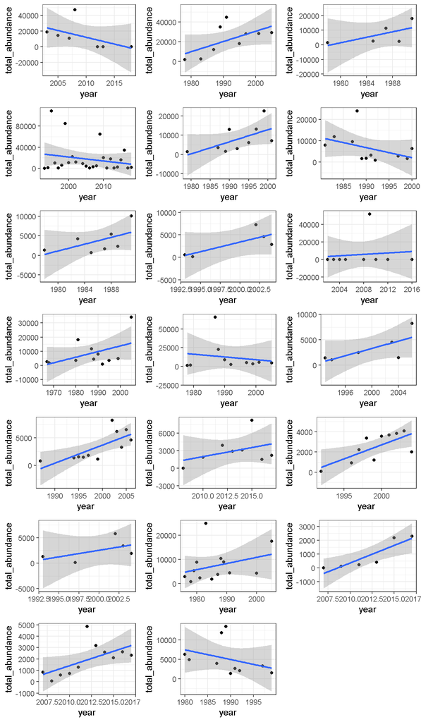

```r
p_high_slope_abun <- map(site_desc_slope_total_abundance[1:20],
  ~plot_community_data(
    analysis_dataset %>%
    filter(siteid == .x) %>%
    select(siteid, year, total_abundance),
    y = "total_abundance", x = "year",
  smoothing_method = "lm"))
plot_grid(plotlist = p_high_slope_abun, ncol = 3)
```

```r
s11735_com <- analysis_dataset %>%
  filter(siteid == site_desc_slope_total_abundance[1]) %>%
  arrange(year) %>%
  select(siteid, year, total_abundance)
s11735_com
```

```
#> # A tibble: 7 x 3
#>   siteid  year total_abundance
#>   <chr>  <dbl>           <dbl>
#> 1 S1661   2003       18900
#> 2 S1661   2005       14500
#> 3 S1661   2007       10700
#> 4 S1661   2008       47200
#> 5 S1661   2012           0.129
#> 6 S1661   2013           0.154
#> 7 S1661   2018           0.066
```

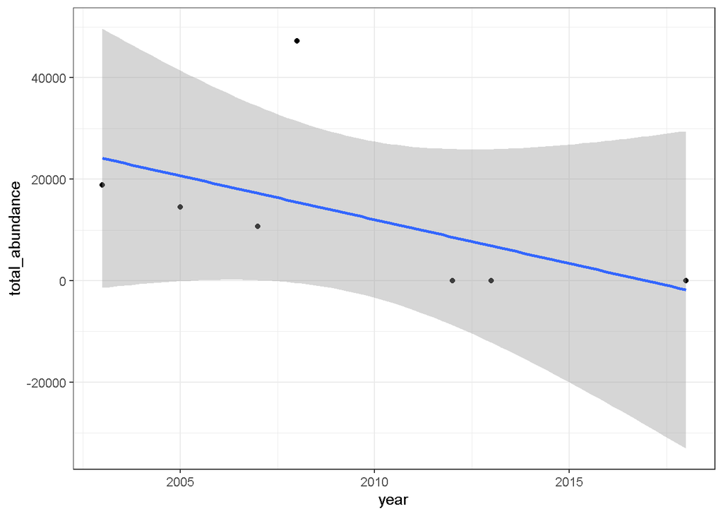

```r
plot_community_data(s11735_com, y = "total_abundance", x = "year",
  smoothing_method = "lm")
```

```r
mean(s11735_com$total_abundance) -  sd(s11735_com$total_abundance)
```

```
#> [1] -3883.247
```

```r
mean(s11735_com$total_abundance) +  5 * sd(s11735_com$total_abundance)
```

```
#> [1] 97673.67
```

```r
s11735_pop <- filtered_dataset$measurement %>%
  filter(siteid == site_desc_slope_total_abundance[1]) %>%
  arrange(year) %>%
  select(siteid, year, species, abundance)

s11735_pop %>%
  group_by(species) %>%
  summarise(abun = sum(abundance)) %>%
  arrange(desc(abun))
```

```
#> # A tibble: 13 x 2
#>    species                abun
#>    <chr>                 <dbl>
#>  1 Leuciscus leuciscus  26600.
#>  2 Rutilus rutilus      25700.
#>  3 Gobio gobio          13600.
#>  4 Perca fluviatilis    11200.
#>  5 Alburnus alburnus     4800.
#>  6 Anguilla anguilla     3700.
#>  7 Squalius cephalus     2500.
#>  8 Esox lucius           2000.
#>  9 Tinca tinca            400
#> 10 Gymnocephalus cernua   300.
#> 11 Barbus barbus          200
#> 12 Cyprinus carpio        200
#> 13 Abramis brama          100.
```

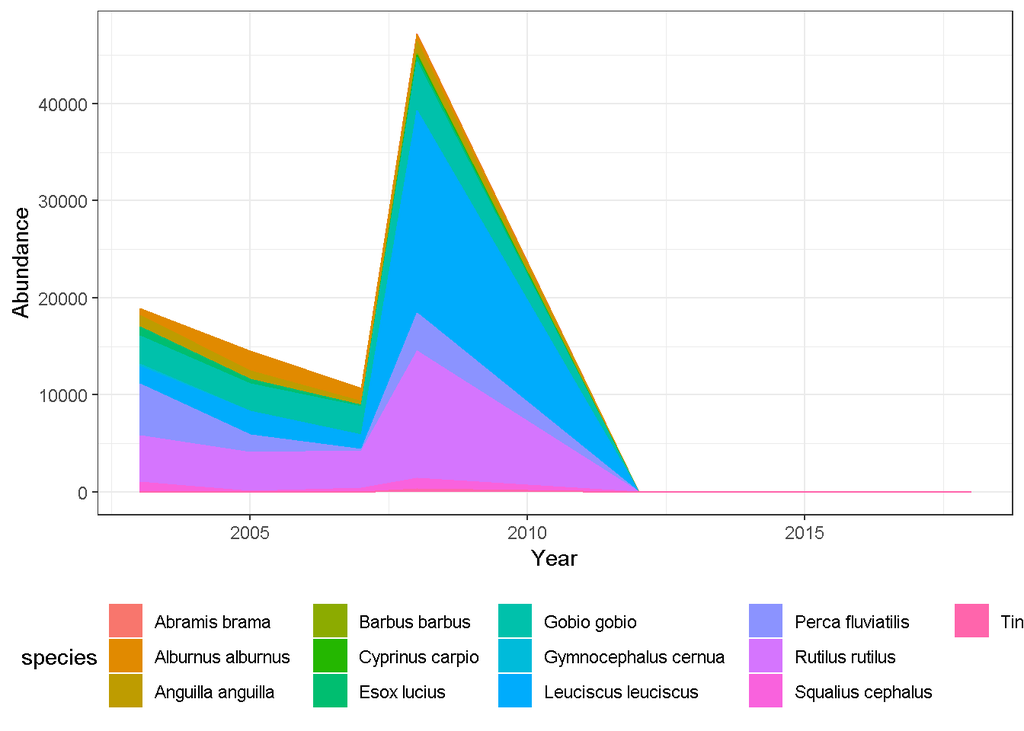

```r
plot_temporal_population(s11735_pop) +
  theme(legend.position = "bottom")
```

- Second highest temporal trends in abundance:

```r
s6466_com <- analysis_dataset %>%
  filter(siteid == site_desc_slope_total_abundance[2]) %>%
  arrange(year) %>%
  select(siteid, year, total_abundance)
s6466_com
```

```
#> # A tibble: 9 x 3
#>   siteid  year total_abundance
#>   <chr>  <dbl>           <dbl>
#> 1 S524    1978            1861
#> 2 S524    1983            2739
#> 3 S524    1987           12032
#> 4 S524    1989           34800
#> 5 S524    1991           44608
#> 6 S524    1995           17982
#> 7 S524    1997           27971
#> 8 S524    2001           28139
#> 9 S524    2005           29259
```

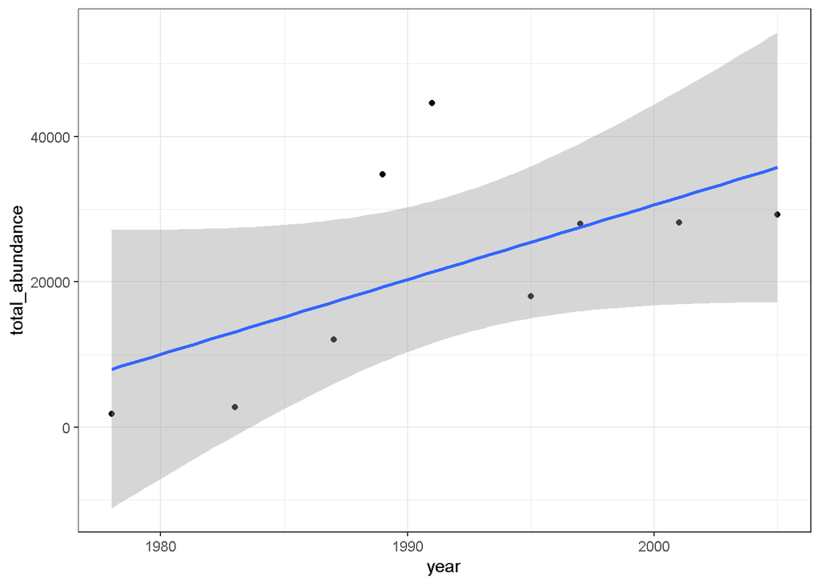

```r
plot_community_data(s6466_com, y = "total_abundance", x = "year",
  smoothing_method = "lm")
```

```r
s6466_pop <- filtered_dataset$measurement %>%
  filter(siteid == site_desc_slope_total_abundance[2]) %>%
  arrange(year) %>%
  select(siteid, year, species, abundance)

s6466_pop %>%
  group_by(species) %>%
  summarise(abun = sum(abundance)) %>%
  arrange(desc(abun))
```

```
#> # A tibble: 55 x 2
#>    species                abun
#>    <chr>                 <dbl>
#>  1 Dorosoma cepedianum   93893
#>  2 Dorosoma petenense    68072
#>  3 Aplodinotus grunniens 14574
#>  4 Ictalurus furcatus     9962
#>  5 Ictalurus punctatus    5411
#>  6 Alosa chrysochloris    3645
#>  7 Notropis wickliffi      545
#>  8 Pylodictis olivaris     465
#>  9 Morone saxatilis        444
#> 10 Pomoxis annularis       429
#> # ... with 45 more rows
```

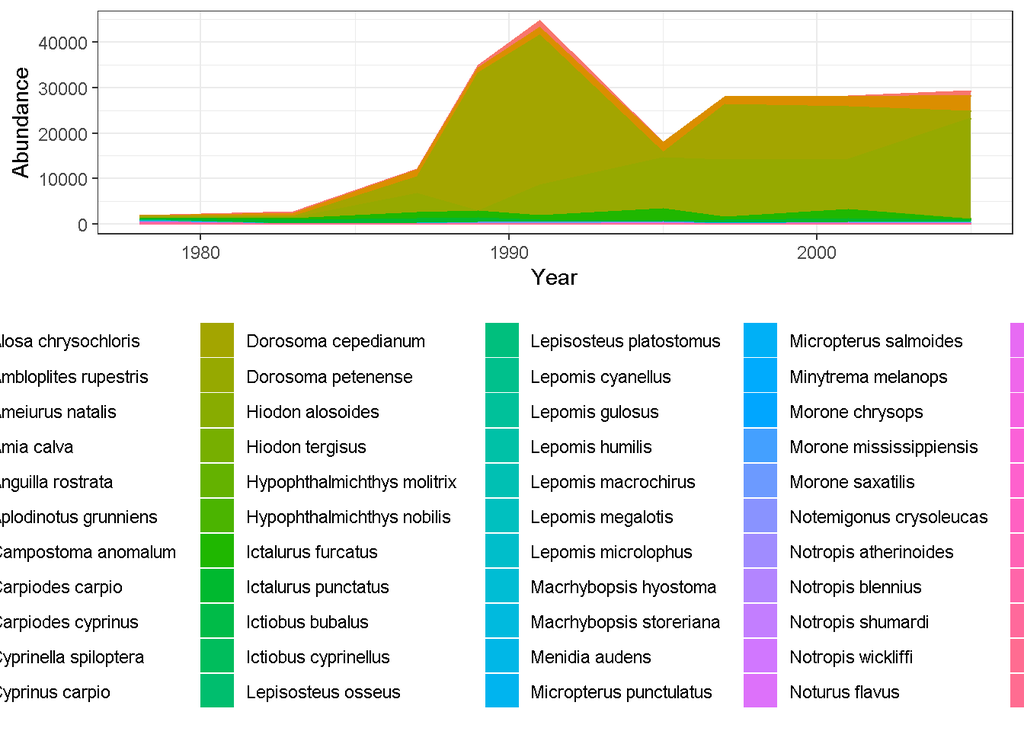

```r
plot_temporal_population(s6466_pop) +
  theme(legend.position = "bottom")
```

# 3 Relationships among temporal trends

## 3.1 Globally

```r
cor_slope <- slope_df %>%
  select(-siteid) %>%
  cor(., method = "spearman")
cor_slope
```

```
#>                     total_abundance log_total_abundance  species_nb
#> total_abundance        1.0000000000        0.8246307994  0.31807533
#> log_total_abundance    0.8246307994        1.0000000000  0.40301195
#> species_nb             0.3180753260        0.4030119484  1.00000000
#> log_species_nb         0.2892004606        0.4052594645  0.93758602
#> chao_richness          0.0508961756        0.1394440304  0.80433662
#> chao_shannon          -0.0279137551        0.0477362851  0.59176245
#> chao_simpson          -0.0338305788        0.0191291401  0.48346752
#> chao_evenness         -0.0444857958        0.0009310158  0.17645002
#> jaccard               -0.0491817382       -0.0517691046 -0.08847793
#> horn                  -0.0456593373       -0.0471057146 -0.07711548
#> chao                  -0.0027001396       -0.0262558468 -0.01843873
#> hillebrand            -0.0203384951       -0.0071825278 -0.06012651
#> total                  0.0719557567        0.0788475302  0.16716036
#> appearance             0.2268847971        0.2929139747  0.69631041
#> disappearance         -0.1710111291       -0.2509080868 -0.58273933
#> evenness              -0.1304340666       -0.0971770501  0.19029318
#> shannon               -0.0004716725        0.0813750746  0.60038484
#> simpson               -0.0141998364        0.0516382845  0.48153130
#> jaccard_dis            0.0491429875        0.0517029275  0.08864262
#> nestedness             0.0345864709        0.0430393920  0.14269762
#> turnover               0.0132785000       -0.0069467758 -0.04408210
#>                     log_species_nb chao_richness chao_shannon chao_simpson
#> total_abundance         0.28920046    0.05089618  -0.02791376  -0.03383058
#> log_total_abundance     0.40525946    0.13944403   0.04773629   0.01912914
#> species_nb              0.93758602    0.80433662   0.59176245   0.48346752
#> log_species_nb          1.00000000    0.79445957   0.64663632   0.55175635
#> chao_richness           0.79445957    1.00000000   0.69826636   0.56653555
#> chao_shannon            0.64663632    0.69826636   1.00000000   0.94157972
#> chao_simpson            0.55175635    0.56653555   0.94157972   1.00000000
#> chao_evenness           0.24923947    0.19437940   0.65705554   0.69265391
#> jaccard                -0.09704400   -0.09635087  -0.07884636  -0.07917356
#> horn                   -0.08126924   -0.08544403  -0.06734601  -0.07002592
#> chao                   -0.03482762   -0.02808783  -0.02116922  -0.02728646
#> hillebrand             -0.05626267   -0.06552551  -0.08700625  -0.09673906
#> total                   0.17660072    0.16318394   0.12898031   0.11747598
#> appearance              0.73091884    0.60465541   0.48732557   0.42063453
#> disappearance          -0.62969158   -0.48910181  -0.40547117  -0.34222041
#> evenness                0.28946517    0.30909021   0.71480914   0.76973418
#> shannon                 0.66069142    0.66738929   0.94205155   0.90503802
```

[output cut: 77 more lines]

```
#> chao_simpson         0.091619608 -0.033710423
#> chao_evenness        0.003239198 -0.012526122
#> jaccard             -0.464244804 -0.509148654
#> horn                -0.418463495 -0.535620536
#> chao                -0.350854086 -0.137217564
#> hillebrand          -0.164497385 -0.353682040
#> total                0.453373854  0.491791029
#> appearance           0.296077412  0.371254096
#> disappearance        0.058750950  0.570190549
#> evenness             0.047331331 -0.046223059
#> shannon              0.120328105 -0.063519018
#> simpson              0.100141306 -0.064334629
#> jaccard_dis          0.464283551  0.509189404
#> nestedness           1.000000000 -0.389647237
#> turnover            -0.389647237  1.000000000
```

```r
png(here("doc", "fig", "p_cor_slope.png"))
corrplot::corrplot(cor_slope[c("chao_richness", "species_nb", "log_species_nb",
      "total_abundance", "log_total_abundance"), ], type = "upper", tl.srt = 45, diag = FALSE)
dev.off()
```

```r
png(here("doc", "fig", "p_cor_slope_tot.png"))
corrplot::corrplot(cor_slope, type = "upper", tl.srt = 35, diag = FALSE)
dev.off()
```

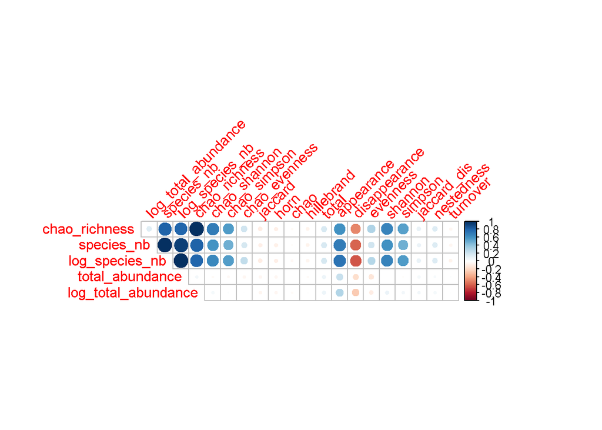

```r
corrplot::corrplot(cor_slope[c("chao_richness", "species_nb", "log_species_nb",
      "total_abundance", "log_total_abundance"), ], type = "upper", tl.srt = 45, diag = FALSE)
```

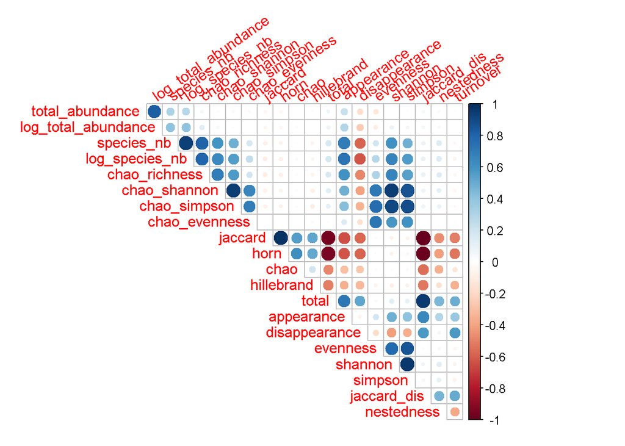

```r
corrplot::corrplot(cor_slope, type = "upper", tl.srt = 35, diag = FALSE)
```

```r
ti <- expand.grid(
  resp1 = unique(slope$response),
  resp2 = unique(slope$response)
  ) %>%
  filter(resp2 != resp1) %>%
  filter(
    resp1 %in% c("chao_richness", "species_nb", "log_species_nb",
      "total_abundance", "log_total_abundance")) %>%
  mutate_all(as.character) %>%
  arrange(resp1)

test <- map2(ti$resp1, ti$resp2,
  function(x, y) {
    bi <- slope %>%
      filter(response %in% c(x, y)) %>%
      select(siteid, response, linear_slope) %>%
      pivot_wider(names_from = "response", values_from = "linear_slope")

    return(bi)
  }
)

p_trends_trends <- map(test, function(x) {
  l <- colnames(x)
  x %>%
    ggplot(aes(x = !!sym(l[2]), y = !!sym(l[3]))) +
    geom_point() +
    geom_smooth(method = "loess") +
    labs(
      x = get_var_replacement()[l[2]],
      y = get_var_replacement()[l[3]]
    )
})
names(p_trends_trends) <- map_chr(test, ~colnames(.x)[2])
```

## 3.2 Total abundance

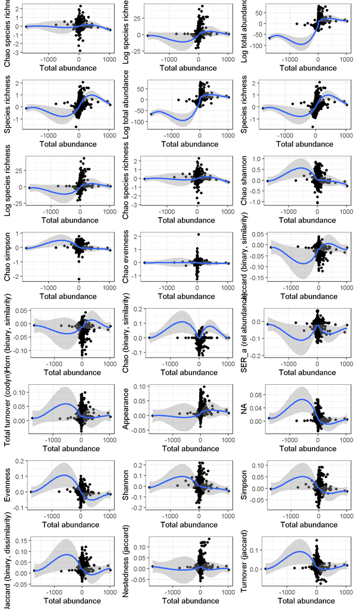

```r
plot_grid(
  plotlist = p_trends_trends[names(p_trends_trends) %in% "total_abundance"],
  ncol = 3)
```

## 3.3 Species richness

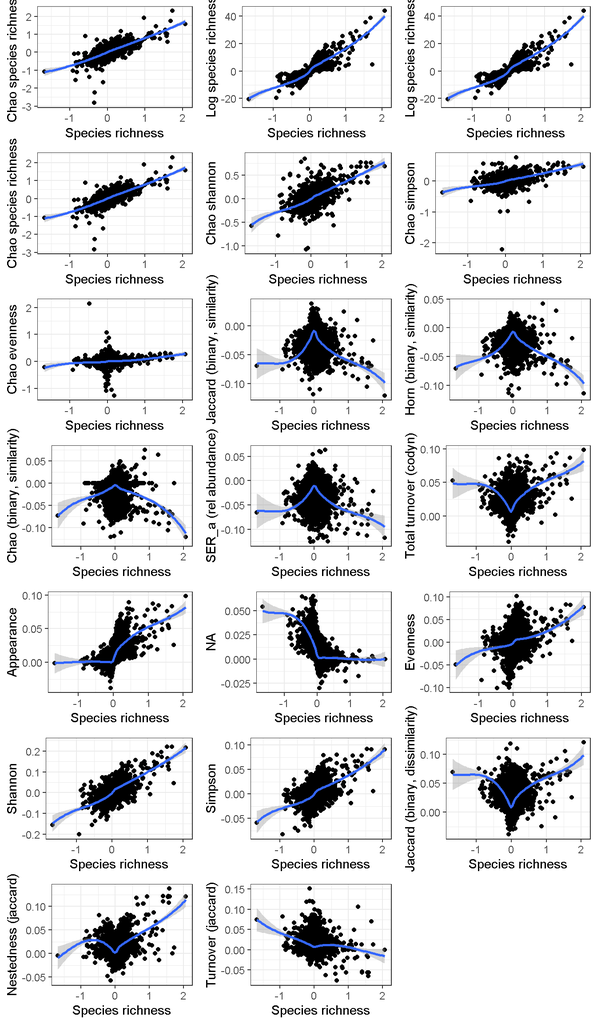

```r
plot_grid(
  plotlist = p_trends_trends[names(p_trends_trends) %in% "species_nb"],
  ncol = 3)
```

## 3.4 Log species richness

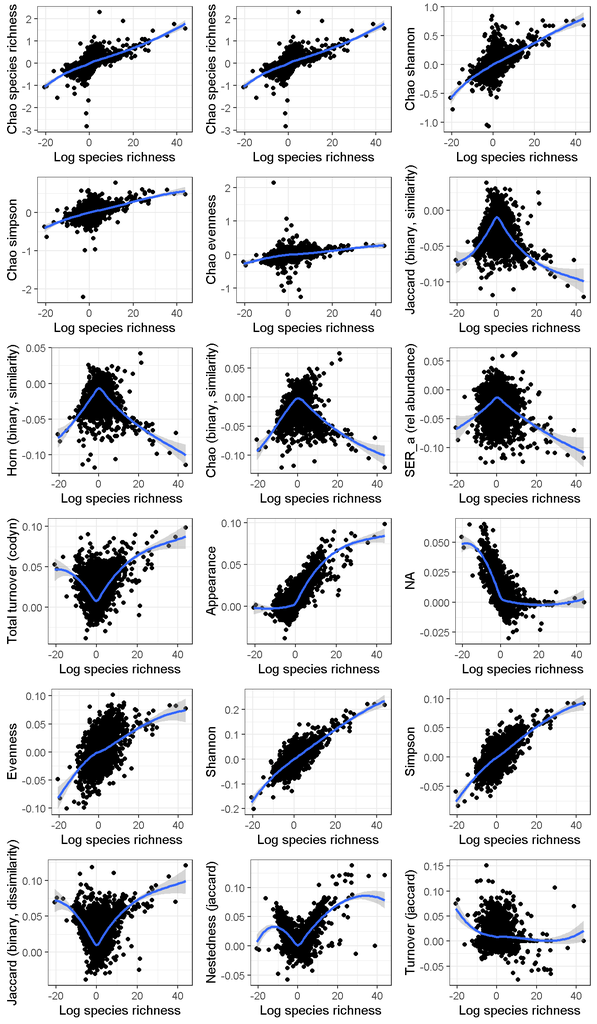

```r
plot_grid(
  plotlist = p_trends_trends[names(p_trends_trends) %in% "log_species_nb"],
  ncol = 3
)
```

- Trends of total abundance are linked to the one of species richness but not to shannon and simpson, suggesting that the trends of abundance are more link to trends of rare species. Logic: gain and loss of species should concern rare species.
- Species richness decrease linked to disappearance, but not increase
- Species richness increase linked to appearance, but not decrease

## 3.5 Turnover vs nestedness:

```r
test <- slope_df %>%
  mutate(
    nes_sup_tu = nestedness > turnover,
    nes_inf_tu = nestedness < turnover,
    rich_inc = species_nb >= 0
  )
sum(test$nes_sup_tu)
```

```
#> [1] 2608
```

```r
sum(test$nes_inf_tu)
```

```
#> [1] 2603
```

```r
test %>%
  tabyl(rich_inc, nes_sup_tu) %>%
  adorn_totals("row") %>%
  adorn_title(placement = "top")
```

```
#>           nes_sup_tu
#>  rich_inc      FALSE TRUE
#>     FALSE       1408 1037
#>      TRUE       1500 1571
#>     Total       2908 2608
```

```r
median_site_rich <- analysis_dataset %>%
  select(c("siteid", starts_with("chao_"), "total_abundance")) %>%
  group_by(siteid) %>%
  summarise(across(where(is.double), median)) %>%
  rename_with(~paste0("med_", .x), where(is.double))
```

```r
slope_df_med <- slope_df %>%
  left_join(median_site_rich, by = "siteid") %>%
  mutate(
    nes_sup_tu = nestedness > turnover,
    nes_inf_tu = nestedness < turnover,
    rich_inc = species_nb >= 0
  )
```

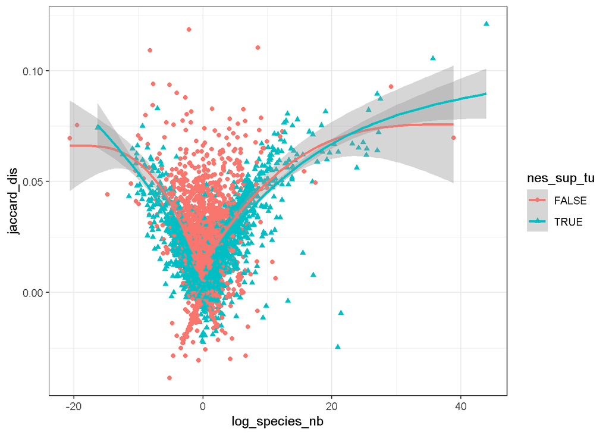

```r
slope_df_med %>%
  ggplot(aes(
      x = log_species_nb,
      y = jaccard_dis,
      shape = nes_sup_tu,
      color = nes_sup_tu
      )) +
  geom_point() +
  geom_smooth(method = "gam")
```

[figure not shown]

```r
p_baselga_jaccard <- map(c("nestedness", "turnover"),
  ~slope_df_med %>%
    ggplot(aes(
        x = jaccard_dis,
        y = !!sym(.x),
      color = log(med_chao_richness))) +
    geom_point() +
    scale_color_viridis() +
    geom_abline(intercept = 0, slope = 1) +
    geom_smooth(method = "loess")
)
p_baselga_jaccard[[3]] <-
  slope_df_med %>%
  ggplot(aes(
      x = jaccard_dis,
      y = nestedness - turnover,
      color = log(med_chao_richness))) +
  geom_point() +
  scale_color_viridis() +
  geom_abline(intercept = 0, slope = 1) +
  geom_smooth(method = "loess")

plot_grid(plotlist = p_baselga_jaccard, ncol = 3)
```

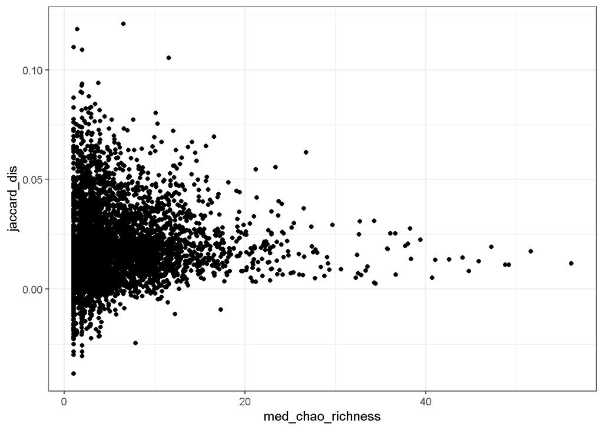

```r
slope_df_med %>%
  ggplot(aes(x = med_chao_richness, y = jaccard_dis)) +
  geom_point()
```

# 4 Look at strong turnover trends

- Check with Jaccard:

```r
high_jaccard_slope <-
  slope_df %>%
  select(siteid, total_abundance, species_nb, jaccard) %>%
  arrange(desc(jaccard))
high_jaccard_slope
```

```
#> # A tibble: 5,516 x 4
#>    siteid total_abundance species_nb jaccard
#>    <chr>            <dbl>      <dbl>   <dbl>
#>  1 S6544            0.257   -0.0769   0.0385
#>  2 S8076           -1.99    -0.0383   0.0307
#>  3 S7264            1.16     0.0600   0.0300
#>  4 S6550            1.92     0.116    0.0286
#>  5 S5095           -3.37    -0.0857   0.0286
#>  6 S7806            0.760   -0.0394   0.0285
#>  7 S2742            1.08    -0.00909  0.0258
#>  8 S6783            0.508   -0.0500   0.0250
#>  9 S450           120.       0.870    0.0247
#> 10 S12595          13.6     -0.0421   0.0228
#> # ... with 5,506 more rows
```

```r
site_desc_jaccard_slope <-
  high_jaccard_slope %>%
  .[["siteid"]]
```

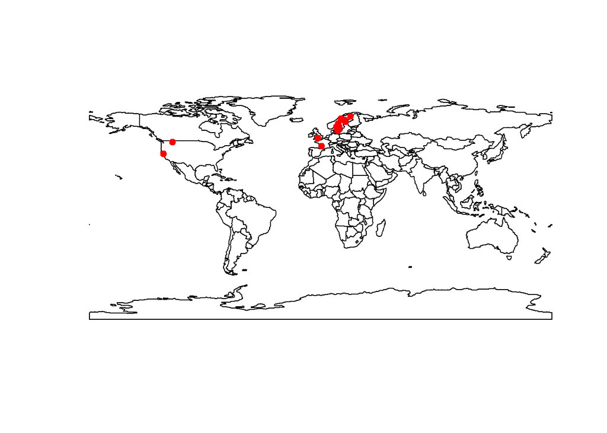

```r
ti <- filtered_dataset$location %>%
  filter(siteid %in% site_desc_jaccard_slope[1:20]) %>%
  st_as_sf(coords = c("longitude", "latitude"), crs = 2154)

sp::plot(ne_countries())
sp::plot(st_geometry(ti), add = TRUE, col = "red", pch = 19)
```

```r
filtered_dataset$abun_rich_op %>%
  filter(siteid %in% site_desc_jaccard_slope[1:20]) %>%
  group_by(siteid) %>%
  summarise(across(c("total_abundance", "species_nb"),
      list(median = median, mean = mean))) %>%
  kable() %>%
  kable_styling(bootstrap_options = c("striped", "bordered", "hover")) %>%
  scroll_box(width = "100%", height = "400px")
```

| siteid | total_abundance_median | total_abundance_mean | species_nb_median | species_nb_mean |
| --- | --- | --- | --- | --- |
| S12595 | 347.000 | 341.62632 | 1.0 | 1.368421 |
| S2742 | 41.900 | 57.09091 | 2.0 | 2.000000 |
| S2831 | 170.500 | 180.15455 | 1.0 | 1.272727 |
| S450 | 877.500 | 744.66667 | 12.5 | 9.166667 |
| S5095 | 37.900 | 52.81667 | 1.0 | 1.333333 |
| S5190 | 56.600 | 82.35714 | 2.0 | 1.857143 |
| S5514 | 25.900 | 23.58000 | 1.5 | 1.700000 |
| S5672 | 6.400 | 41.36000 | 2.0 | 1.800000 |
| S6544 | 15.000 | 18.06154 | 1.0 | 1.307692 |
| S6550 | 6.650 | 14.55714 | 2.0 | 2.214286 |
| S6783 | 10.100 | 12.24667 | 1.0 | 1.200000 |
| S6936 | 22.800 | 26.62500 | 1.0 | 1.333333 |
| S7264 | 11.300 | 10.94000 | 1.0 | 1.400000 |
| S7288 | 8.100 | 15.01667 | 3.0 | 3.333333 |
| S7342 | 13.039 | 13.71067 | 4.0 | 3.833333 |
| S7532 | 1.900 | 1.84000 | 1.0 | 1.400000 |
| S7806 | 10.200 | 10.95000 | 1.0 | 1.222222 |
| S8076 | 65.000 | 72.50000 | 2.0 | 2.250000 |
| S8447 | 10.700 | 11.00000 | 4.0 | 3.750000 |
| S998 | 34.100 | 36.39412 | 1.0 | 1.235294 |

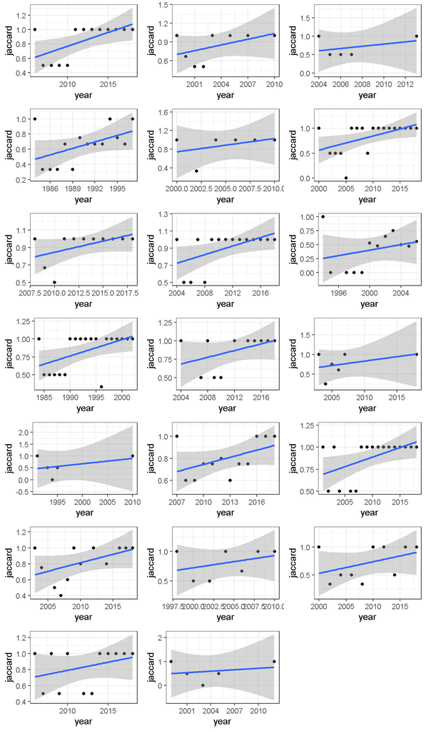

```r
p_high_jaccard_slope <- map(site_desc_jaccard_slope[1:20],
  ~plot_community_data(
    analysis_dataset %>%
    filter(siteid == .x) %>%
    select(siteid, year, jaccard),
    y = "jaccard", x = "year",
  smoothing_method = "lm"))
plot_grid(plotlist = p_high_jaccard_slope, ncol = 3)
```

- Hum, do not understand why community are more similar at the end of the time-steps

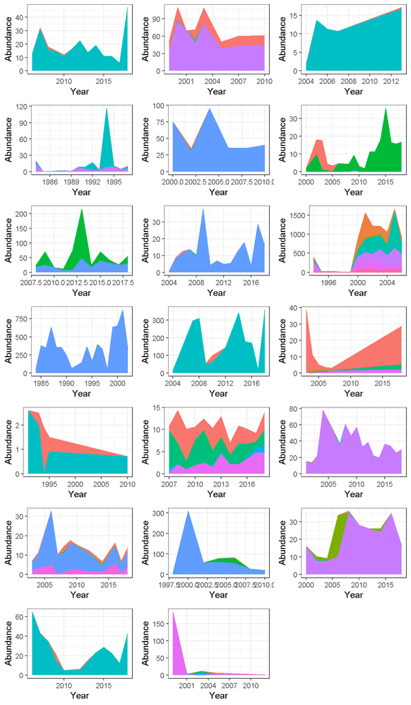

```r
p_pop_high_jaccard <-
  map(site_desc_jaccard_slope[1:20],
    ~plot_temporal_population(
      filtered_dataset$measurement %>%
        filter(siteid == .x)
      ) +
    theme(legend.position = "none")
    )
plot_grid(plotlist = p_pop_high_jaccard, ncol = 3)
```

- Lets see communities that becomes more dissimilar:

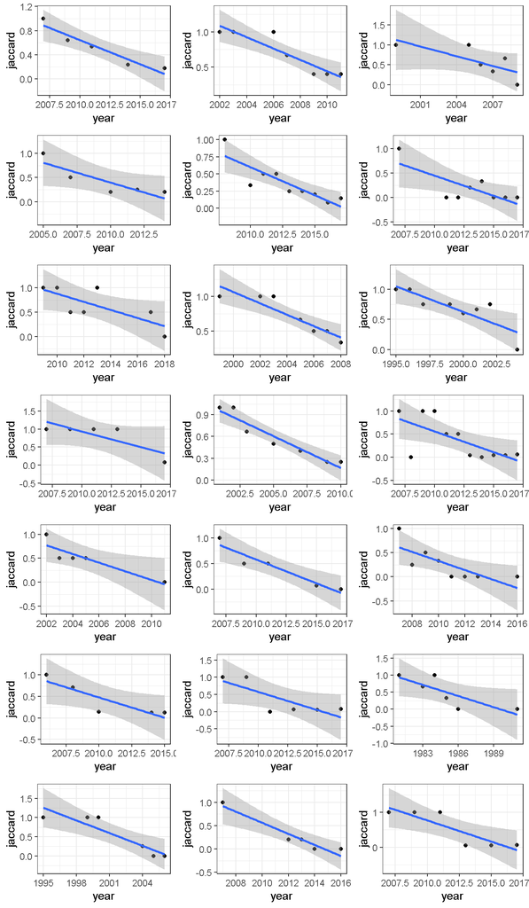

```r
p_jaccard_low_jaccard <-
  map(site_desc_jaccard_slope[(length(site_desc_jaccard_slope)-20):length(site_desc_jaccard_slope)],
    ~plot_community_data(
      analysis_dataset %>%
        filter(siteid == .x) %>%
        select(siteid, year, jaccard),
      y = "jaccard", x = "year",
      smoothing_method = "lm"))
plot_grid(plotlist = p_jaccard_low_jaccard, ncol = 3)
```

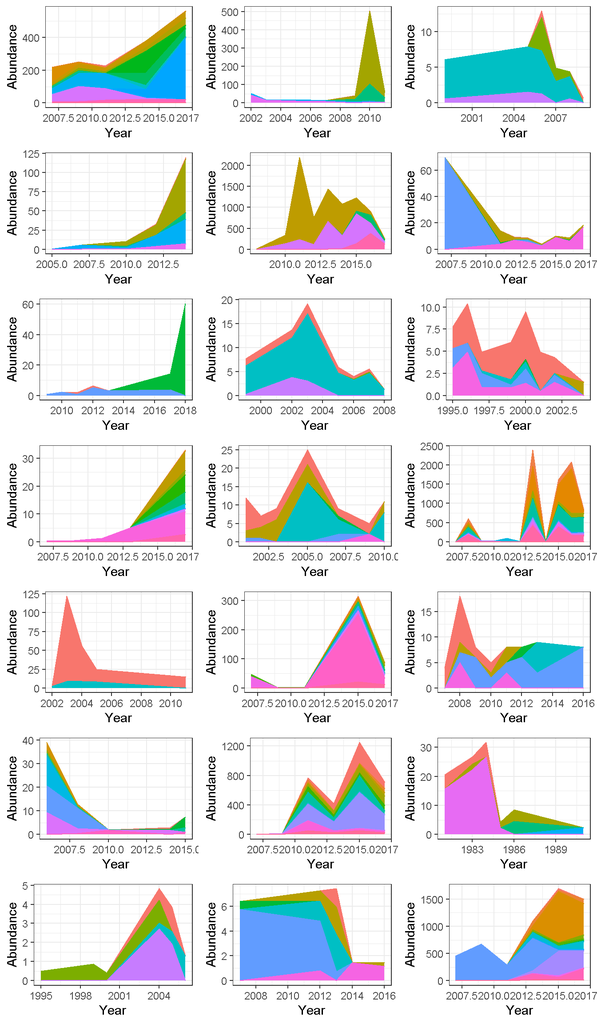

```r
p_pop_low_jaccard <-
  map(site_desc_jaccard_slope[
    (length(site_desc_jaccard_slope)-20):length(site_desc_jaccard_slope)],
    ~plot_temporal_population(
      filtered_dataset$measurement %>%
        filter(siteid == .x)
      ) +
    theme(legend.position = "none")
    )
plot_grid(plotlist = p_pop_low_jaccard, ncol = 3)
```

# 5 Comparison rigal, lm

```r
rigal_trends_df <-  map2_dfr(
  rigal_trends, names(rigal_trends),
  ~.x %>% mutate(variable = .y)
  ) %>%
  select(variable, siteid, linear_slope) %>%
  pivot_wider(names_from = "variable", values_from = "linear_slope") %>%
  mutate(type = "rigal")
```

```r
slope_comp <- list()
slope_comp$rigal <- rigal_trends_df[order(rigal_trends_df$siteid), ]
slope_comp$simple_lm <- slope_df[order(slope_df$siteid), ]
stopifnot(all(slope_comp$rigal$siteid == slope_comp$simple_lm$siteid))
slope_comp$diff <- tibble(
  siteid = slope_comp$rigal$siteid)
for (i in var_temporal_trends) {
  slope_comp$diff[[i]] <- slope_comp$rigal[[i]] - slope_comp$simple_lm[[i]]
}
```

- All good !

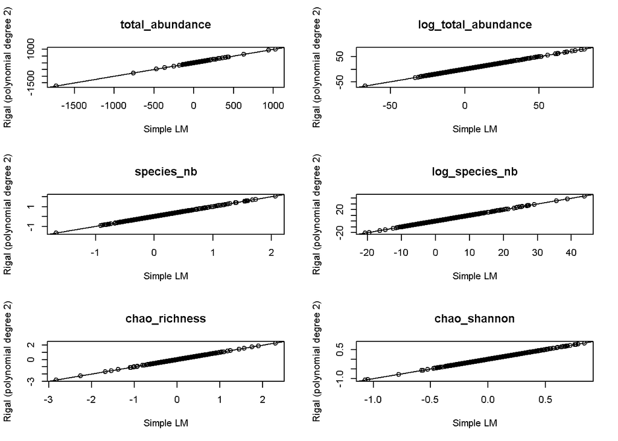

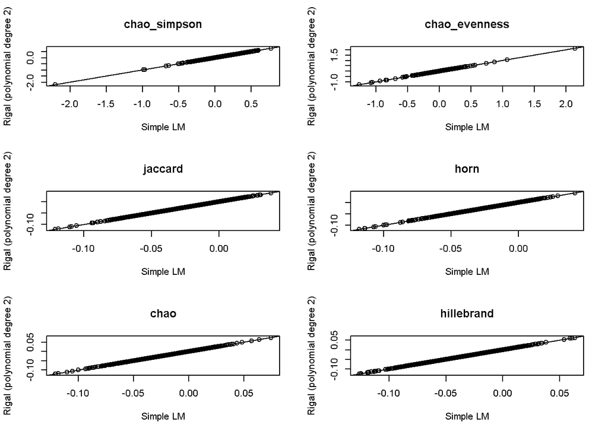

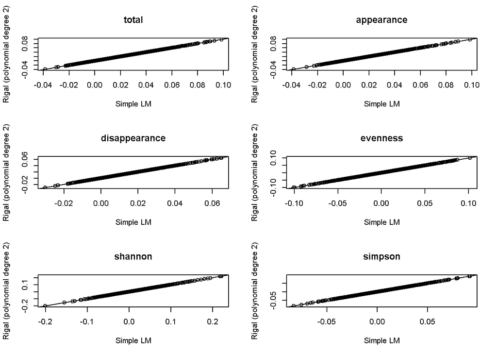

```r
old_par <- par()
par(mfrow = c(3, 2))
for (i in var_temporal_trends) {
  plot(
    slope_comp$rigal[[i]] ~
      slope_comp$simple_lm[[i]],
    ylab = "Rigal (polynomial degree 2)",
    xlab = "Simple LM"
  )
  abline(0, 1)
  title(i)
}
```

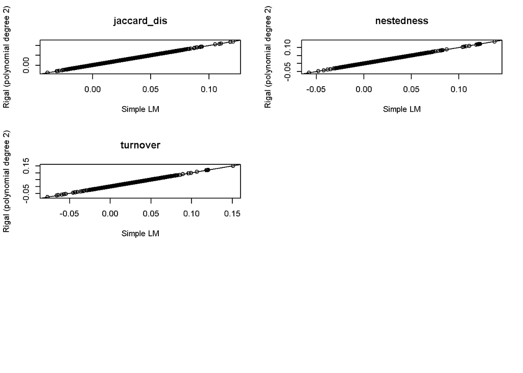

```r
par(old_par)
```

```r
# Compare Rigal and simple lm for few sites
plot_rigal_raw_data <- function(
  site = NULL,
  response = NULL,
  dataset = NULL,
  rigal_trends = NULL
  ) {

  raw_data <- dataset %>%
    filter(siteid == site)
  rigal_resp <- rigal_trends[[response]]
  rigal_resp_site <- rigal_resp[rigal_resp$siteid == site, ]
  plot(raw_data[[response]]~raw_data[["year"]], ylab = response, xlab = "Year")
  abline(rigal_resp_site$intercept, rigal_resp_site$linear_slope, col
  = "red")
  abline(lm(raw_data[[response]]~raw_data[["year"]]), col = "green")
  title(main = site)
}
```

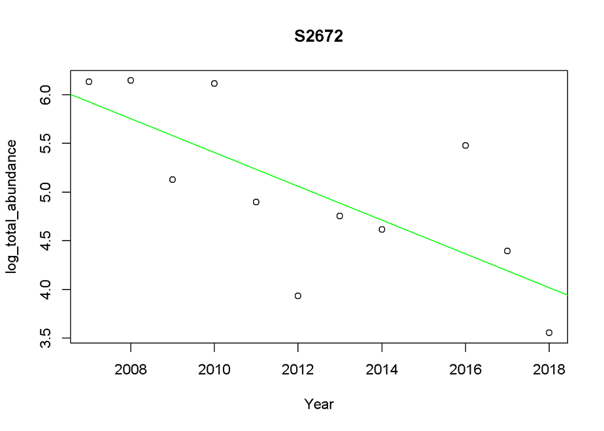

```r
plot_rigal_raw_data(site = "S2672", response = "log_total_abundance", dataset =
analysis_dataset, rigal_trends = rigal_trends)
```

```r
slope_comp$diff <- slope_comp$diff %>%
  arrange(desc(abs(log_total_abundance)))
```

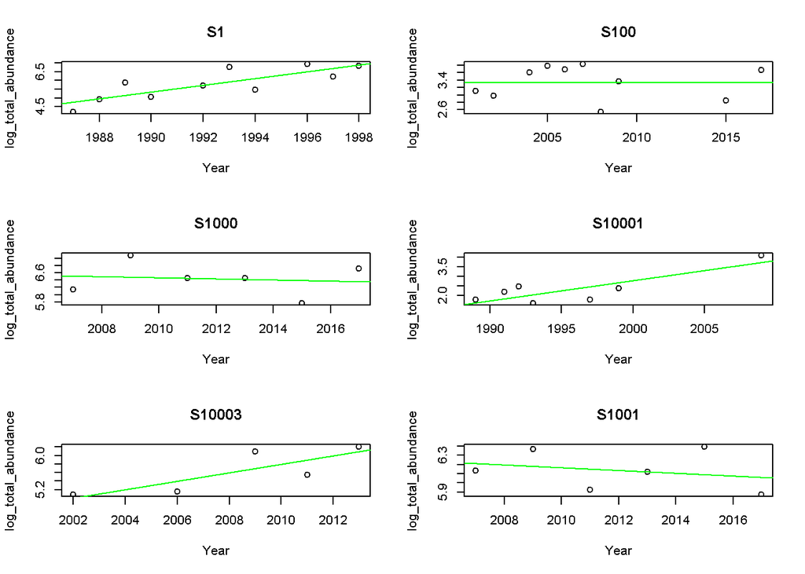

```r
old_par <- par()
par(mfrow = c(3, 2))
for (i in slope_comp$diff[1:6,]$siteid) {
  plot_rigal_raw_data(
    site = i,
    response = "log_total_abundance",
    dataset = analysis_dataset,
    rigal_trends = rigal_trends
  )
}
```

```r
par(old_par)
```

# 6 Classification of temporal trends

- Classification:

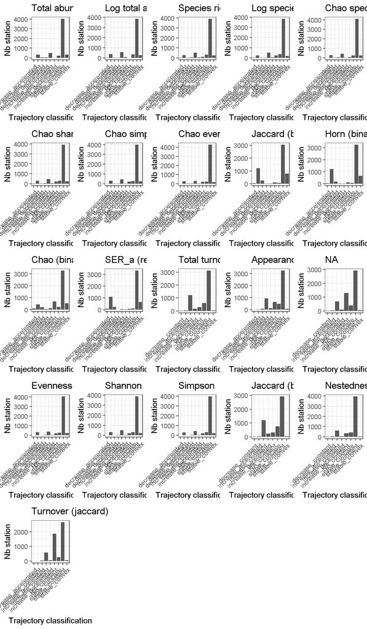

```r
classification_station <- map2(rigal_trends, names(rigal_trends),
  ~.x %>%
  ggplot(aes(x = shape_class)) +
  geom_bar() +
  labs(x = "Trajectory classification", y = "Nb station",
    title = get_var_replacement()[.y]) +
  theme(axis.text.x = element_text(angle = 45, vjust = 1, hjust=1))
)


plot_grid(plotlist = classification_station)
```

```r
p_classif_abun_rich <- plot_grid(
  plotlist = classification_station[
    names(classification_station)[str_detect(names(classification_station),
  "abundance|richness|species")]])
save_plot(
  here("doc", "fig", "classif_trends_abun_rich.png"),
  p_classif_abun_rich
)
p_classif_hill_evenness <- plot_grid(
  plotlist = classification_station[
    names(classification_station)[str_detect(names(classification_station),
  "shannon|simpson|evennes")]])
save_plot(
  here("doc", "fig", "classif_trends_hill_evenness.png"),
  p_classif_hill_evenness
)
p_classif_turnover <- plot_grid(
  plotlist = classification_station[
    names(classification_station)[names(classification_station) %in%
      c("jaccard", "horn", "chao", "hillebrand", "total", "appearance",
        "disappearance")]])
save_plot(
  here("doc", "fig", "classif_trends_classif_hill_evenness.png"),
  p_classif_turnover
)
```

```r
ti <- map_dfr(rigal_trends, ~tabyl_df(x = .x, group = "direction"),
  .id = "response"
)
ti %>%
  filter(direction != "Total") %>%
  select(response, direction, percent) %>%
  mutate(response = str_replace_all(response, get_var_replacement())) %>%
  pivot_wider(names_from = "direction", values_from = "percent") %>%
  kable() %>%
  kable_styling(bootstrap_options = c("striped", "bordered", "hover"))
```

[output not shown]

- Linear trends:

```r
#3.3   Log-linear model:logYi=α+βXi+εiIn

#the log-linear model, the literal interpretation of the estimated
#coefficientˆβis that a one-unitincrease inXwill produce an expected increase in
#logYofˆβunits.
#In terms ofYitself, this
#meansthat  the  expected  value  ofYis  multiplied  byeˆβ.   So  in  terms  of
#effects  of  changes  inXonY(unlogged):•Each 1-unit increase inXmultiplies the
#expected value ofYbyeˆβ.•To compute the effects onYof another change inXthan an
#increase of one unit, call thischangec, we need to includecin the exponent.  The
#effect of ac-unit increase inXis tomultiply the expected value ofYbyecˆβ. So the
#effect for a 5-unit increase inXwould bee5ˆβ.•For small values ofˆβ,
#approximatelyeˆβ≈1+ˆβ. We can use this for the following approxima-tion for a
#quick interpretation of the coefficients:  100·ˆβis the expected percentage
#changeinYfor a unit increase inX.  For instance forˆβ=.06,e.06≈1.06, so a 1-unit
#change inXcorresponds to (approximately) an expected increase inYof 6%
```

[output not shown]

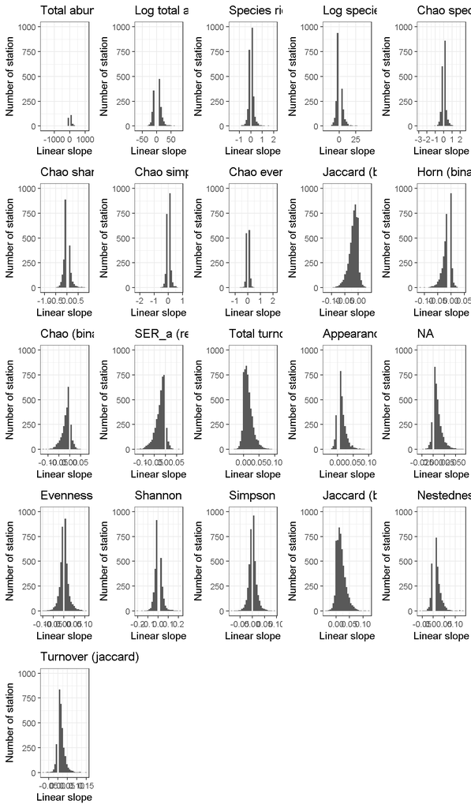

```r
#https://data.library.virginia.edu/interpreting-log-transformations-in-a-linear-model/
hist_linear_plot <- map2(rigal_trends, names(rigal_trends),
  ~.x %>%
  ggplot(aes(x = linear_slope)) +
  geom_histogram() +
  labs(x = "Linear slope", y = "Number of station",
    title = get_var_replacement()[.y]) +
  ylim(c(0, 1000))
)
plot_grid(plotlist = hist_linear_plot)
```

```r
type_response <- list(
  abun_rich = str_detect(names(classification_station),
    "abundance|richness|species"),
  hill_evenness = str_detect(names(classification_station),
    "shannon|simpson|evennes"),
  turnover = names(classification_station) %in%
    c("jaccard", "horn", "chao", "hillebrand", "total", "appearance",
      "disappearance")
)

map2(type_response, names(type_response),
  function(x, y) {
  p <- plot_grid(
    plotlist = hist_linear_plot[
      names(hist_linear_plot)[x]
      ]
  )
  save_plot(
    here("doc", "fig", paste0("hist_linear_slope_", y, ".png")),
    p
  )

  }
)
```

[output not shown]

# 7 Spatialization of temporal trends

```r
rigal_trends_df_loc <-
  rigal_trends_df %>%
  left_join(
    select(filtered_dataset$location, siteid, ecoregion, country),
    by = c("siteid"))
```

- No obvious geographic patterns

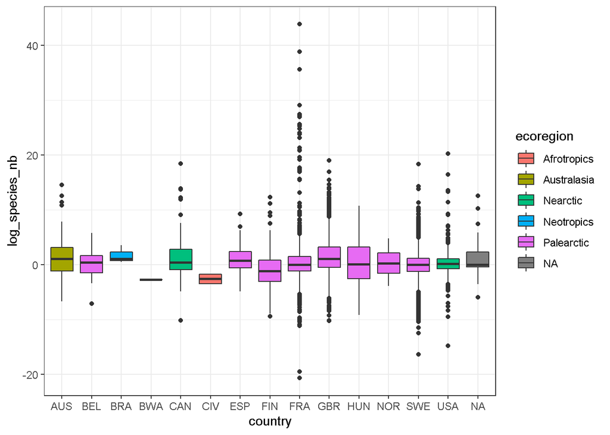

```r
rigal_trends_df_loc %>%
  ggplot(aes(x = country, y = log_species_nb, fill = ecoregion)) +
  geom_boxplot()
```

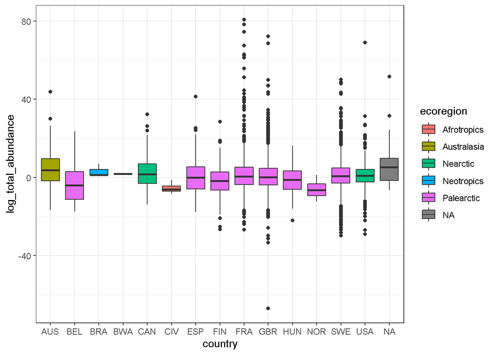

```r
rigal_trends_df_loc %>%
  ggplot(aes(x = country, y = log_total_abundance, fill = ecoregion)) +
  geom_boxplot()
```

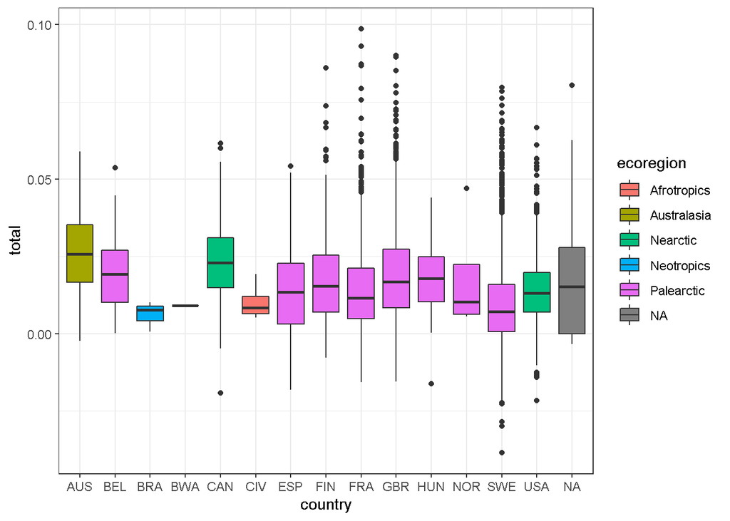

```r
rigal_trends_df_loc %>%
  ggplot(aes(x = country, y = total, fill = ecoregion)) +
  geom_boxplot()
```